# HW3_Jie He

# Q3

# a

```r
print("Y = 50 + 20*GPA + 0.07*IQ + 35*Gender + 0.01*GPA:IQ + (-10)*GPA:Gender")
```

```
## [1] "Y = 50 + 20*GPA + 0.07*IQ + 35*Gender + 0.01*GPA:IQ + (-10)*GPA:Gender"
```

1. and ii) are incorrect because the coefficient of GPA:Gender is negative. GPA does have an effect on Y. If GPA is high enough (above 3.5), male will make more money than female and thus iii) is correct and iv) is incorrect. Male: Y = 50 + 20*GPA + 0.07*IQ + 0.01*GPA:IQ Female: Y = 50 + 20*GPA + 0.07*IQ + 35 + 0.01*GPA:IQ + (-10)*GPA

# b

```r
Y = 50 + 20*4.0 + 0.07*110 + 35 + 0.01*(4.0*110) + (-10)*4.0
print(paste0("this specific female has a salary: ", Y, " thousand dollars"))
```

```
## [1] "this specific female has a salary: 137.1 thousand dollars"
```

# c

False! Compared with all the other predictors, IQ has the biggest scale. IQ(0-200); Gender(0 or 1); GPA(0-4) If all predictors have the same level of impact on response, the coefficients of IQ related terms should be relatively smaller.

# Q9

# e

```r
#load data set
library(ISLR)
data(Auto)
#test multiple combinations
int_no <- lm(mpg~displacement+weight+year+origin, data=Auto) #no interactions
int1 <- lm(mpg~displacement+weight+year*origin, data=Auto)
int2 <- lm(mpg~displacement+origin+year*weight, data=Auto)
int3 <- lm(mpg~displacement+year+weight*origin, data=Auto)
int4 <- lm(mpg~year+origin+displacement*weight, data=Auto)

#int5 <- lm(mpg~displacement+weight+year:origin, data=Auto)
#int6 <- lm(mpg~displacement+origin+year:weight, data=Auto)
#int7 <- lm(mpg~displacement+year+weight:origin, data=Auto)
#int8 <- lm(mpg~year+origin+displacement:weight, data=Auto)

summary(int_no) #no interactions
```

```
##
## Call:
## lm(formula = mpg ~ displacement + weight + year + origin, data = Auto)
##
## Residuals:
##     Min      1Q  Median      3Q     Max
## -9.8102 -2.1129 -0.0388  1.7725 13.2085
##
## Coefficients:
##                Estimate Std. Error t value Pr(>|t|)
## (Intercept)  -1.861e+01  4.028e+00  -4.620 5.25e-06 ***
## displacement  5.588e-03  4.768e-03   1.172    0.242
## weight       -6.575e-03  5.571e-04 -11.802  < 2e-16 ***
## year          7.714e-01  4.981e-02  15.486  < 2e-16 ***
## origin        1.226e+00  2.670e-01   4.593 5.92e-06 ***
## ---
## Signif. codes:  0 '***' 0.001 '**' 0.01 '*' 0.05 '.' 0.1 ' ' 1
##
## Residual standard error: 3.346 on 387 degrees of freedom
## Multiple R-squared:  0.8181, Adjusted R-squared:  0.8162
## F-statistic: 435.1 on 4 and 387 DF,  p-value: < 2.2e-16
```

```r
summary(int1)
```

```
##
## Call:
## lm(formula = mpg ~ displacement + weight + year * origin, data = Auto)
##
## Residuals:
##     Min      1Q  Median      3Q     Max
## -8.7541 -1.8722 -0.0936  1.6900 12.4650
##
## Coefficients:
##                Estimate Std. Error t value Pr(>|t|)
## (Intercept)   7.927e+00  8.873e+00   0.893 0.372229
## displacement  1.551e-03  4.859e-03   0.319 0.749735
## weight       -6.394e-03  5.526e-04 -11.571  < 2e-16 ***
## year          4.313e-01  1.130e-01   3.818 0.000157 ***
## origin       -1.449e+01  4.707e+00  -3.079 0.002225 **
## year:origin   2.023e-01  6.047e-02   3.345 0.000904 ***
## ---
## Signif. codes:  0 '***' 0.001 '**' 0.01 '*' 0.05 '.' 0.1 ' ' 1
##
## Residual standard error: 3.303 on 386 degrees of freedom
## Multiple R-squared:  0.8232, Adjusted R-squared:  0.8209
## F-statistic: 359.5 on 5 and 386 DF,  p-value: < 2.2e-16
```

```r
summary(int2)
```

```
##
## Call:
## lm(formula = mpg ~ displacement + origin + year * weight, data = Auto)
##
## Residuals:
##     Min      1Q  Median      3Q     Max
## -8.9402 -1.8736 -0.0966  1.5924 12.2125
##
## Coefficients:
##                Estimate Std. Error t value Pr(>|t|)
## (Intercept)  -1.076e+02  1.290e+01  -8.339 1.34e-15 ***
## displacement -4.020e-04  4.558e-03  -0.088 0.929767
## origin        9.116e-01  2.547e-01   3.579 0.000388 ***
## year          1.962e+00  1.716e-01  11.436  < 2e-16 ***
## weight        2.605e-02  4.552e-03   5.722 2.12e-08 ***
## year:weight  -4.305e-04  5.967e-05  -7.214 2.89e-12 ***
## ---
## Signif. codes:  0 '***' 0.001 '**' 0.01 '*' 0.05 '.' 0.1 ' ' 1
##
## Residual standard error: 3.145 on 386 degrees of freedom
## Multiple R-squared:  0.8397, Adjusted R-squared:  0.8376
## F-statistic: 404.4 on 5 and 386 DF,  p-value: < 2.2e-16
```

```r
summary(int3)
```

```
##
## Call:
## lm(formula = mpg ~ displacement + year + weight * origin, data = Auto)
##
## Residuals:
##      Min       1Q   Median       3Q      Max
## -10.5713  -2.0781  -0.1988   1.6305  12.6939
##
## Coefficients:
##                 Estimate Std. Error t value Pr(>|t|)
## (Intercept)   -2.669e+01  4.317e+00  -6.183 1.61e-09 ***
## displacement  -4.049e-03  5.116e-03  -0.791  0.42922
## year           7.751e-01  4.861e-02  15.945  < 2e-16 ***
## weight        -2.767e-03  1.002e-03  -2.762  0.00602 **
## origin         6.718e+00  1.241e+00   5.413 1.09e-07 ***
## weight:origin -2.404e-03  5.311e-04  -4.526 8.01e-06 ***
## ---
## Signif. codes:  0 '***' 0.001 '**' 0.01 '*' 0.05 '.' 0.1 ' ' 1
##
## Residual standard error: 3.265 on 386 degrees of freedom
## Multiple R-squared:  0.8273, Adjusted R-squared:  0.825
## F-statistic: 369.7 on 5 and 386 DF,  p-value: < 2.2e-16
```

```r
summary(int4)
```

```
##
## Call:
## lm(formula = mpg ~ year + origin + displacement * weight, data = Auto)
##
## Residuals:
##      Min       1Q   Median       3Q      Max
## -10.6119  -1.7290  -0.0115   1.5609  12.5584
##
## Coefficients:
##                       Estimate Std. Error t value Pr(>|t|)
## (Intercept)         -8.007e+00  3.798e+00  -2.108   0.0357 *
## year                 8.194e-01  4.518e-02  18.136  < 2e-16 ***
## origin               3.567e-01  2.574e-01   1.386   0.1666
## displacement        -7.148e-02  9.176e-03  -7.790 6.27e-14 ***
## weight              -1.054e-02  6.530e-04 -16.146  < 2e-16 ***
## displacement:weight  2.104e-05  2.214e-06   9.506  < 2e-16 ***
## ---
## Signif. codes:  0 '***' 0.001 '**' 0.01 '*' 0.05 '.' 0.1 ' ' 1
##
## Residual standard error: 3.016 on 386 degrees of freedom
## Multiple R-squared:  0.8526, Adjusted R-squared:  0.8507
## F-statistic: 446.5 on 5 and 386 DF,  p-value: < 2.2e-16
```

```r
#summary(int5)
#summary(int6)
#summary(int7)
#summary(int8)
```

Based on the results(p-values of interactions < 0.05), all of the interactions seem to be statistically significant.

# f

```r
#test log(X), X^0.5, and X^2 transformations
lm1 <- lm(mpg~displacement+I(sqrt(weight))+year+origin, data=Auto)
lm2 <- lm(mpg~displacement+I(log(weight))+year+origin, data=Auto)
lm3 <- lm(mpg~displacement+I(weight^2)+year+origin, data=Auto)

summary(lm1)
```

```
##
## Call:
## lm(formula = mpg ~ displacement + I(sqrt(weight)) + year + origin,
##     data = Auto)
##
## Residuals:
##     Min      1Q  Median      3Q     Max
## -9.7348 -2.0154  0.0539  1.6762 13.0776
##
## Coefficients:
##                  Estimate Std. Error t value Pr(>|t|)
## (Intercept)      2.514591   4.305605   0.584   0.5595
## displacement     0.008465   0.004422   1.915   0.0563 .
## I(sqrt(weight)) -0.784635   0.057758 -13.585  < 2e-16 ***
## year             0.790391   0.047908  16.498  < 2e-16 ***
## origin           1.030154   0.257008   4.008 7.34e-05 ***
## ---
## Signif. codes:  0 '***' 0.001 '**' 0.01 '*' 0.05 '.' 0.1 ' ' 1
##
## Residual standard error: 3.211 on 387 degrees of freedom
## Multiple R-squared:  0.8325, Adjusted R-squared:  0.8308
## F-statistic: 480.9 on 4 and 387 DF,  p-value: < 2.2e-16
```

```r
summary(lm2)
```

```
##
## Call:
## lm(formula = mpg ~ displacement + I(log(weight)) + year + origin,
##     data = Auto)
##
## Residuals:
##     Min      1Q  Median      3Q     Max
## -9.7136 -1.9214  0.0447  1.5790 12.9864
##
## Coefficients:
##                  Estimate Std. Error t value Pr(>|t|)
## (Intercept)    131.274483  11.082986  11.845  < 2e-16 ***
## displacement     0.007711   0.004052   1.903 0.057810 .
## I(log(weight)) -21.584745   1.451851 -14.867  < 2e-16 ***
## year             0.804835   0.046532  17.296  < 2e-16 ***
## origin           0.836143   0.250485   3.338 0.000925 ***
## ---
## Signif. codes:  0 '***' 0.001 '**' 0.01 '*' 0.05 '.' 0.1 ' ' 1
##
## Residual standard error: 3.113 on 387 degrees of freedom
## Multiple R-squared:  0.8425, Adjusted R-squared:  0.8409
## F-statistic: 517.7 on 4 and 387 DF,  p-value: < 2.2e-16
```

```r
summary(lm3)
```

```
##
## Call:
## lm(formula = mpg ~ displacement + I(weight^2) + year + origin,
##     data = Auto)
##
## Residuals:
##      Min       1Q   Median       3Q      Max
## -10.0988  -2.2549  -0.1057   1.8704  13.4702
##
## Coefficients:
##                Estimate Std. Error t value Pr(>|t|)
## (Intercept)  -2.609e+01  4.349e+00  -5.999 4.56e-09 ***
## displacement -9.114e-03  5.118e-03  -1.781   0.0757 .
## I(weight^2)  -7.068e-07  9.075e-08  -7.789 6.28e-14 ***
## year          7.336e-01  5.380e-02  13.635  < 2e-16 ***
## origin        1.488e+00  2.900e-01   5.132 4.56e-07 ***
## ---
## Signif. codes:  0 '***' 0.001 '**' 0.01 '*' 0.05 '.' 0.1 ' ' 1
##
## Residual standard error: 3.628 on 387 degrees of freedom
## Multiple R-squared:  0.7861, Adjusted R-squared:  0.7839
## F-statistic: 355.7 on 4 and 387 DF,  p-value: < 2.2e-16
```

From the results, we can see that all these models are good because they all have high F-statistic values and low p-values associated with. I(sqrt(weight)), I(log(weight)), and I(weight^2) are all statistically significant since they all have p-values less than 0.05.

# Q10

# a

```r
#load data set
library(ISLR)
data(Carseats)
summary(Carseats)
```

```
##      Sales          CompPrice       Income        Advertising
##  Min.   : 0.000   Min.   : 77   Min.   : 21.00   Min.   : 0.000
##  1st Qu.: 5.390   1st Qu.:115   1st Qu.: 42.75   1st Qu.: 0.000
##  Median : 7.490   Median :125   Median : 69.00   Median : 5.000
##  Mean   : 7.496   Mean   :125   Mean   : 68.66   Mean   : 6.635
##  3rd Qu.: 9.320   3rd Qu.:135   3rd Qu.: 91.00   3rd Qu.:12.000
##  Max.   :16.270   Max.   :175   Max.   :120.00   Max.   :29.000
##    Population        Price        ShelveLoc        Age
##  Min.   : 10.0   Min.   : 24.0   Bad   : 96   Min.   :25.00
##  1st Qu.:139.0   1st Qu.:100.0   Good  : 85   1st Qu.:39.75
##  Median :272.0   Median :117.0   Medium:219   Median :54.50
##  Mean   :264.8   Mean   :115.8                Mean   :53.32
##  3rd Qu.:398.5   3rd Qu.:131.0                3rd Qu.:66.00
##  Max.   :509.0   Max.   :191.0                Max.   :80.00
##    Education    Urban       US
##  Min.   :10.0   No :118   No :142
##  1st Qu.:12.0   Yes:282   Yes:258
##  Median :14.0
##  Mean   :13.9
##  3rd Qu.:16.0
##  Max.   :18.0
```

```r
#fit regression model
fit.lm <- lm(Sales~Price+Urban+US, data=Carseats)
summary(fit.lm)
```

```
##
## Call:
## lm(formula = Sales ~ Price + Urban + US, data = Carseats)
##
## Residuals:
##     Min      1Q  Median      3Q     Max
## -6.9206 -1.6220 -0.0564  1.5786  7.0581
##
## Coefficients:
##              Estimate Std. Error t value Pr(>|t|)
## (Intercept) 13.043469   0.651012  20.036  < 2e-16 ***
## Price       -0.054459   0.005242 -10.389  < 2e-16 ***
## UrbanYes    -0.021916   0.271650  -0.081    0.936
## USYes        1.200573   0.259042   4.635 4.86e-06 ***
## ---
## Signif. codes:  0 '***' 0.001 '**' 0.01 '*' 0.05 '.' 0.1 ' ' 1
##
## Residual standard error: 2.472 on 396 degrees of freedom
## Multiple R-squared:  0.2393, Adjusted R-squared:  0.2335
## F-statistic: 41.52 on 3 and 396 DF,  p-value: < 2.2e-16
```

# b

From https://cran.r-project.org/web/packages/ISLR/ISLR.pdf, we can get the info of the data set. Sales is about unit sales in thousands at each location. Price is about price charged for car seats at each site. Urban is about whether the store is in a rural or urban location. (two levels Yes or No) US is about whether the store is in US or not. (two levels Yes or No)

Coefs: Price(-0.054459): When price increases by $1, sales decrease by 54.459(rounded to 54 for unit). It is statistically significant. UrbanYes(-0.021916): If the store is in an urban location, sales are 21.916(rounded to 22 for unit) lower. It is not statistically significat. USYes(1.200573): If the store is in US, sales are 1200.573(rounded to 1201 for unit) higher. It is statistically significant.

# c

Sales = 13.043469 + (-0.054459)*Price + (-0.021916)*UrbanYes + 1.200573*USYes

# d

We can reject the null hypothesis for Price and USYes because the p-values of their coefficients are small.

# e

```r
#fit the data with a two-predictor model
fit.lm_1 <- lm(Sales ~ Price + US, data=Carseats)
summary(fit.lm_1)
```

```
##
## Call:
## lm(formula = Sales ~ Price + US, data = Carseats)
##
## Residuals:
##     Min      1Q  Median      3Q     Max
## -6.9269 -1.6286 -0.0574  1.5766  7.0515
##
## Coefficients:
##             Estimate Std. Error t value Pr(>|t|)
## (Intercept) 13.03079    0.63098  20.652  < 2e-16 ***
## Price       -0.05448    0.00523 -10.416  < 2e-16 ***
## USYes        1.19964    0.25846   4.641 4.71e-06 ***
## ---
## Signif. codes:  0 '***' 0.001 '**' 0.01 '*' 0.05 '.' 0.1 ' ' 1
##
## Residual standard error: 2.469 on 397 degrees of freedom
## Multiple R-squared:  0.2393, Adjusted R-squared:  0.2354
## F-statistic: 62.43 on 2 and 397 DF,  p-value: < 2.2e-16
```

# f

From the results, we can see that Residual standard error is 2.472 and Multiple R-squared is 0.2393 for model with three predictors; Residual standard error is 2.469 and Multiple R-squared is 0.2393 for model with two predictors. Obviously, the one with two predictors has a relatively small RSE.

# g

```r
confint(fit.lm_1)
```

```
##                   2.5 %      97.5 %
## (Intercept) 11.79032020 14.27126531
## Price       -0.06475984 -0.04419543
## USYes        0.69151957  1.70776632
```

```r
confint(fit.lm_1, level=0.95)
```

```
##                   2.5 %      97.5 %
## (Intercept) 11.79032020 14.27126531
## Price       -0.06475984 -0.04419543
## USYes        0.69151957  1.70776632
```

# h

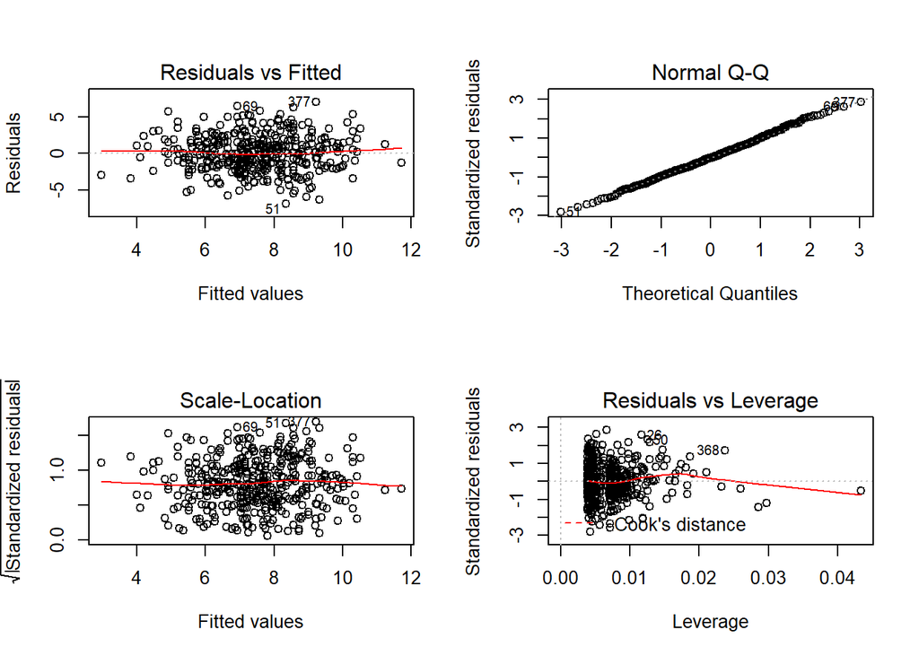

```r
par(mfrow=c(2,2))
plot(fit.lm_1)
#use car library to do plots
library(car)
```

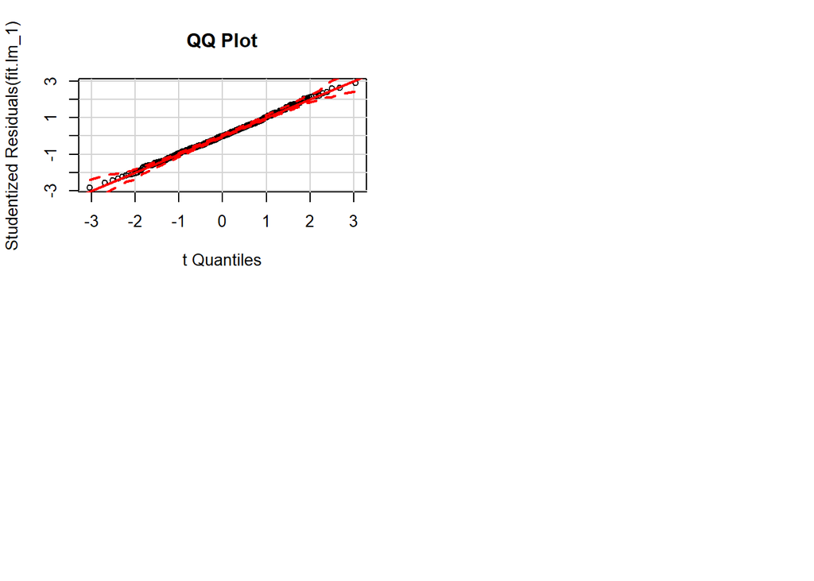

[figure not shown]

```r
qqPlot(fit.lm_1, main="QQ Plot")
leveragePlots(fit.lm_1)
```

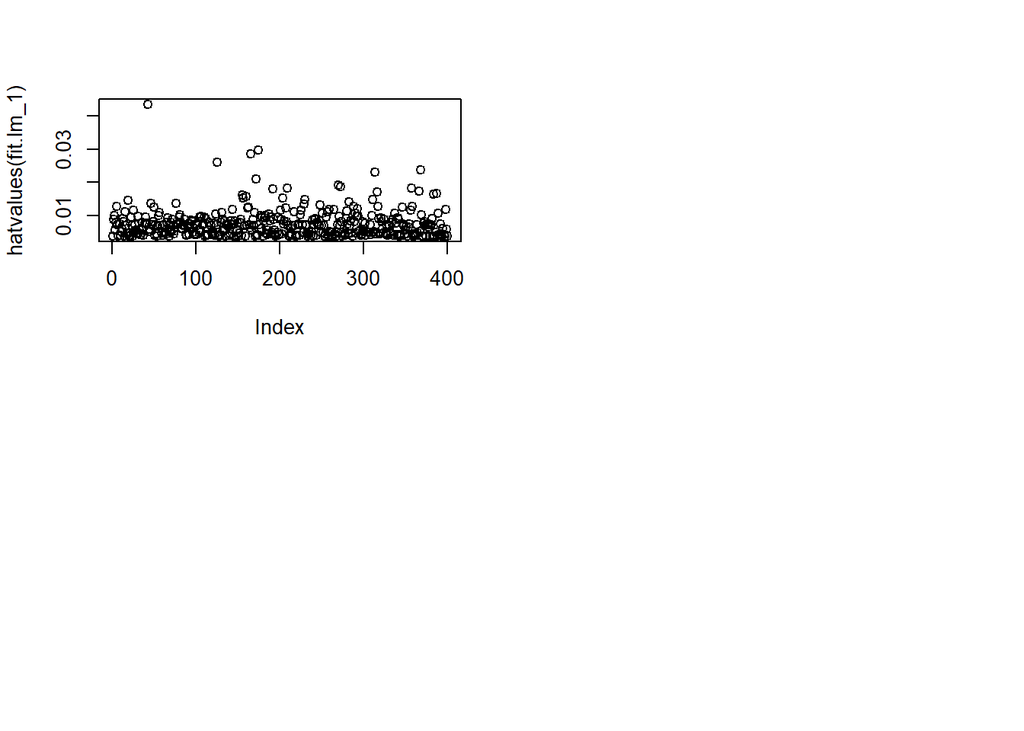

```r
plot(hatvalues(fit.lm_1))
```

The Residuals VS Fitted graph doesn’t show us strong outliers. QQ plot shows no evidence of outliers. Leverage plots show us there might be some leverages.

# Q14

# a

```r
set.seed(1)
x1=runif(100)
x2=0.5*x1+rnorm(100)/10
y=2+2*x1+0.3*x2+rnorm(100)
```

$y = \beta_{0} + \beta_{1}*x_1 + \beta_{2}*x_2 + \epsilon$ $\beta_{0}=2$ $\beta_{1}=2$ $\beta_{2}=0.3$

# b

```r
cor(x1,x2)
```

```
## [1] 0.8351212
```

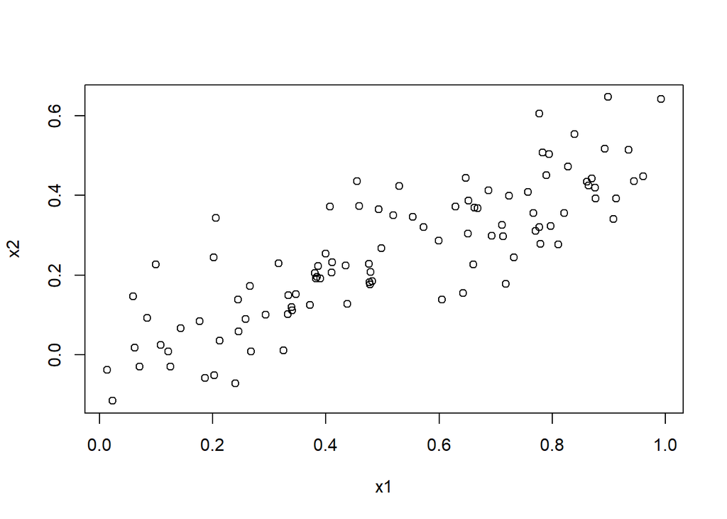

```r
plot(x1,x2)
```

# c

```r
fit.lm <- lm(y~x1+x2)
summary(fit.lm)
```

```
##
## Call:
## lm(formula = y ~ x1 + x2)
##
## Residuals:
##     Min      1Q  Median      3Q     Max
## -2.8311 -0.7273 -0.0537  0.6338  2.3359
##
## Coefficients:
##             Estimate Std. Error t value Pr(>|t|)
## (Intercept)   2.1305     0.2319   9.188 7.61e-15 ***
## x1            1.4396     0.7212   1.996   0.0487 *
## x2            1.0097     1.1337   0.891   0.3754
## ---
## Signif. codes:  0 '***' 0.001 '**' 0.01 '*' 0.05 '.' 0.1 ' ' 1
##
## Residual standard error: 1.056 on 97 degrees of freedom
## Multiple R-squared:  0.2088, Adjusted R-squared:  0.1925
## F-statistic:  12.8 on 2 and 97 DF,  p-value: 1.164e-05
```

We can see from above that $\hat{\beta_{0}}=2.1305$, $\hat{\beta_{1}}=1.4396$, and $\hat{\beta_{2}}=1.0097$. According to the p-values obtained, coefficient of x1 is statistically significant and coefficient of x2 is not statistically significant. Compared with the true $\beta_{0}$, $\beta_{1}$, and $\beta_{2}$, $\hat{\beta_{0}}$ is close to the true value $\hat{\beta_{1}}$ is 1.4396 which is not close to the true value and it has a high SE. $\hat{\beta_{2}}$ is 1.0097 which is not close to the true value and it has a even higher SE than $\hat{\beta_{1}}$. We can thus reject $H_0 : \beta_1=0$ but can’t reject $H_0 : \beta_2=0$ based on p-values.